# Aggregazione dati e struttura DataFrameGroupBy

In questo blog vogliamo mostrare la struttura di un DataFrameGroupBy, ovvero la struttura che si ottiene da un dataframe con operazioni di aggregazione di dati.

# Analisi del problema

Prima di tutto da dati grezzi sotto forma di file CSV, array, dictionari, ecc dobbiamo costruire un dataframe :

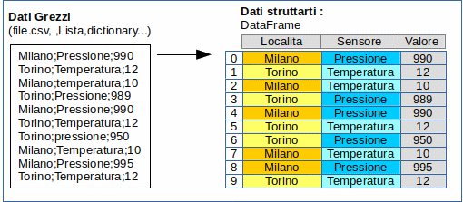

Poi dal dataframe possiamo aggregare i dati per esempio per una colonna :

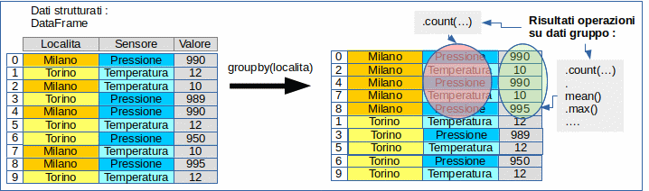

oppure per due colonne :

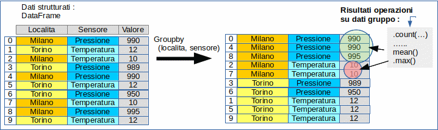

## Scriviamo un po' di codice

#### Importiamo le librerie necessarie

```python
# importa le librerie
%matplotlib inline
import pandas as pd
import numpy as np
```

### Creazione dataframe

Creiamo un dataframe partendo da un dictionary, a sua volta creato tramite array. Il dataframe rappresenta delle misure ottenute da a dei sensori (pressione e temperatura) in diversi periodi, per diverse citta'.

```python
localita =         ['Milano',     'Torino',     'Milano',     'Milano'     ,'Milano'     ,'Milano'     ]
sensore=           ['Temperatura','Temperatura','Temperatura','Pressione'  ,'Pressione'  ,'Pressione'  ]
valore=            [10          ,12          ,  14          ,  998         ,997          ,999          ]
localita=localita+ ['Torino',     'Torino',     'Milano',     'Milano'     ,'Torino'     ,'Torino'  ]
sensore=sensore+   ['Temperatura','Temperatura','Temperatura','Pressione'  ,'Pressione'  ,'Pressione'  ]
valore=valore+     [10          ,12          ,  14          ,  998         ,997         ,999          ]

tabella={'localita':localita,'sensore':sensore,'valore':valore}
df=pd.DataFrame(tabella)
```

|  | localita | sensore | valore |
| --- | --- | --- | --- |
| 0 | Milano | Temperatura | 10 |
| 1 | Torino | Temperatura | 12 |
| 2 | Milano | Temperatura | 14 |
| 3 | Milano | Pressione | 998 |
| 4 | Milano | Pressione | 997 |
| 5 | Milano | Pressione | 999 |
| 6 | Torino | Temperatura | 10 |
| 7 | Torino | Temperatura | 12 |
| 8 | Milano | Temperatura | 14 |
| 9 | Milano | Pressione | 998 |
| 10 | Torino | Pressione | 997 |
| 11 | Torino | Pressione | 999 |

# Aggregazione dati

### Group by su UNA colonna

Proviamo a fare un groupby su una colonna , per esempio la colonna località. Le elaborazioni vengono effettuate sui dati corrispondenti alla localita'.

Quindi come count ho il numero totale degli elemnti per ogni località, mentre come media dei valori numerici ho dei valori non attendibili in qunato ho la media delle pressioni e temperature insieme.

Il tipo dati ottenuto `e 'pandas.core.groupby.groupby.DataFrameGroupBy'

```python
gb=df.groupby('localita')
print("Tipo gb :",type(gb))
gb.describe()
```

```
Tipo gb : <class 'pandas.core.groupby.groupby.DataFrameGroupBy'>
```

| localita | valore count | valore mean | valore std | valore min | valore 25% | valore 50% | valore 75% | valore max |
| --- | --- | --- | --- | --- | --- | --- | --- | --- |
| Milano | 7.0 | 575.714286 | 526.684825 | 10.0 | 14.0 | 997.0 | 998.0 | 999.0 |
| Torino | 5.0 | 406.000000 | 540.420669 | 10.0 | 12.0 | 12.0 | 997.0 | 999.0 |

Calcoliamo medie e conteggi . Se si fanno calcoli numerici su campi non nuemrici si ha un errore (sensore : campo NON numerico, no si puo calcolare la media print(gb.sensore.mean()))

```python
print(gb.sensore)
print(gb.sensore.count())
print(gb.valore.mean())
# sensore : campo NON numerico, no si puo calcolare la media print(gb.sensore.mean())
```

```
<pandas.core.groupby.groupby.SeriesGroupBy object at 0x7f940b46fc18>
localita
Milano    7
Torino    5
Name: sensore, dtype: int64
localita
Milano    575.714286
Torino    406.000000
Name: valore, dtype: float64
```

### groupby su DUE colonne

```python
gb['valore']
```

```
<pandas.core.groupby.groupby.SeriesGroupBy object at 0x7f940b47d710>
```

Effettuiamo un groupby su due colonne (località e sensore). Prima di tutto notiamo che i campi vanno passati come array( tra parentesi quadre). I dati sono aggregati prima per citta e poi per semsore.

```python
gb2=df.groupby(['localita','sensore'])
gb2.describe()
```

| localita | sensore | valore count | valore mean | valore std | valore min | valore 25% | valore 50% | valore 75% | valore max |
| --- | --- | --- | --- | --- | --- | --- | --- | --- | --- |
| Milano | Pressione | 4.0 | 998.000000 | 0.816497 | 997.0 | 997.75 | 998.0 | 998.25 | 999.0 |
|  | Temperatura | 3.0 | 12.666667 | 2.309401 | 10.0 | 12.00 | 14.0 | 14.00 | 14.0 |
| Torino | Pressione | 2.0 | 998.000000 | 1.414214 | 997.0 | 997.50 | 998.0 | 998.50 | 999.0 |
|  | Temperatura | 3.0 | 11.333333 | 1.154701 | 10.0 | 11.00 | 12.0 | 12.00 | 12.0 |

Possiamo quindi avere dei dati per localita e sensore :

```python
print(gb2.valore.mean())
print(gb2.sensore.count())
```

```
localita  sensore
Milano    Pressione      998.000000
          Temperatura     12.666667
Torino    Pressione      998.000000
          Temperatura     11.333333
Name: valore, dtype: float64
localita  sensore
Milano    Pressione      4
          Temperatura    3
Torino    Pressione      2
          Temperatura    3
Name: sensore, dtype: int64
```

## Tipi dati

#### DataFrameGroupBy

L'operazione groupy(...) restituisce un tipo di dato 'pandas.core.groupby.groupby.DataFrameGroupBy'

#### Series

Il tipo di estrazione ottenuta effettuando calcoli su un campo è una pandas.core.Series .

```python
print(type(gb2))
print(type(gb2.valore.mean()))
```

```
<class 'pandas.core.groupby.groupby.DataFrameGroupBy'>
<class 'pandas.core.series.Series'>
```

##### In sintesi :

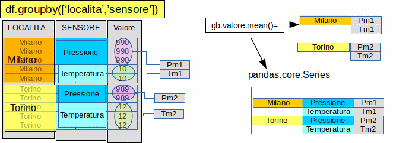

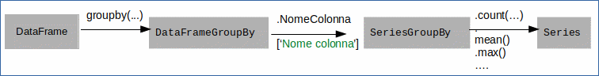

## UNSTACK

Con l'opzione unstack posso spostare una colonna aggregata sulla intestazione. Questa operazione mi trasforma la Series in dataframe, e posso in tale maniera effettuare operazoni specifiche del dataframe . Quindi nel codice sotto eseguimo questa trasformazione :

da groupby --> valore.mean()--> Serie ---> unstack(..) --> dataframe :

```python
# Porto la colonna 0 (localita) sull 'header
df0=gb2.valore.mean().unstack(0)
# Porto la colonna 1 (sensore) sull 'header
df1=gb2.valore.mean().unstack(1)
print("unstack(0) :Porto la colonna 0 (localita) sull 'header\n")
print(df0)
print("\nunstack(1) :Porto la colonna 1 (sensore) sull 'header\n")
print(df1)
```

```
unstack(0) :Porto la colonna 0 (localita) sull 'header

localita         Milano      Torino
sensore
Pressione    998.000000  998.000000
Temperatura   12.666667   11.333333

unstack(1) :Porto la colonna 1 (sensore) sull 'header

sensore   Pressione  Temperatura
localita
Milano        998.0    12.666667
Torino        998.0    11.333333
```

```python
gb2.valore.mean().unstack('sensore')
```

| sensore localita | Pressione | Temperatura |
| --- | --- | --- |
| Milano | 998.0 | 12.666667 |
| Torino | 998.0 | 11.333333 |

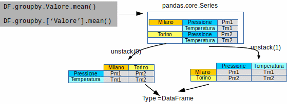

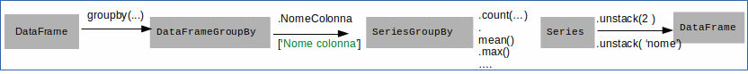

Possiamo fare operazioni sui dati trasformati in dataframe :

```python
print(df0.iloc[0][1])
print(df1.iloc[0][1])
```

```
998.0
12.666666666666666
```